# EDA_v3_final

```python
# import libraries

import pandas as pd
import numpy as np
import seaborn as sns
import matplotlib.pyplot as plt
from datetime import datetime
from sklearn.base import TransformerMixin
import warnings
warnings.filterwarnings('ignore')
% matplotlib inline
```

```python
listing = pd.read_csv('listings.csv')
```

```python
listing.columns # see what features are in the dataset
```

```
Index(['id', 'listing_url', 'scrape_id', 'last_scraped', 'name', 'summary',
       'space', 'description', 'experiences_offered', 'neighborhood_overview',
       'notes', 'transit', 'thumbnail_url', 'medium_url', 'picture_url',
       'xl_picture_url', 'host_id', 'host_url', 'host_name', 'host_since',
       'host_location', 'host_about', 'host_response_time',
       'host_response_rate', 'host_acceptance_rate', 'host_is_superhost',
       'host_thumbnail_url', 'host_picture_url', 'host_neighbourhood',
       'host_listings_count', 'host_total_listings_count',
       'host_verifications', 'host_has_profile_pic', 'host_identity_verified',
       'street', 'neighbourhood', 'neighbourhood_cleansed',
       'neighbourhood_group_cleansed', 'city', 'state', 'zipcode', 'market',
       'smart_location', 'country_code', 'country', 'latitude', 'longitude',
       'is_location_exact', 'property_type', 'room_type', 'accommodates',
       'bathrooms', 'bedrooms', 'beds', 'bed_type', 'amenities', 'square_feet',
       'price', 'weekly_price', 'monthly_price', 'security_deposit',
       'cleaning_fee', 'guests_included', 'extra_people', 'minimum_nights',
       'maximum_nights', 'calendar_updated', 'has_availability',
       'availability_30', 'availability_60', 'availability_90',
       'availability_365', 'calendar_last_scraped', 'number_of_reviews',
       'first_review', 'last_review', 'review_scores_rating',
       'review_scores_accuracy', 'review_scores_cleanliness',
       'review_scores_checkin', 'review_scores_communication',
       'review_scores_location', 'review_scores_value', 'requires_license',
       'license', 'jurisdiction_names', 'instant_bookable',
       'cancellation_policy', 'require_guest_profile_picture',
       'require_guest_phone_verification', 'calculated_host_listings_count',
       'reviews_per_month'],
      dtype='object')
```

```python
# For more concise analysis, only include features that are most relevant and interesting

listing_less = listing[['host_response_time','host_response_rate', 'host_acceptance_rate','host_is_superhost',
                        'host_total_listings_count','host_has_profile_pic', 'host_identity_verified','neighbourhood',
                        'neighbourhood_cleansed','neighbourhood_group_cleansed', 'zipcode',
                        'is_location_exact', 'property_type', 'room_type', 'accommodates','bathrooms', 'bedrooms',
                        'beds', 'bed_type', 'amenities', 'square_feet','price', 'weekly_price', 'monthly_price',
                        'security_deposit','cleaning_fee', 'guests_included', 'extra_people', 'minimum_nights',
                        'maximum_nights','availability_30', 'availability_60',
                        'availability_90','availability_365', 'number_of_reviews','review_scores_rating',
                        'review_scores_accuracy', 'review_scores_cleanliness','review_scores_checkin',
                        'review_scores_communication','review_scores_location', 'review_scores_value',
                        'requires_license','instant_bookable','cancellation_policy', 'require_guest_profile_picture',
                        'require_guest_phone_verification', 'calculated_host_listings_count','reviews_per_month']].copy()
```

```python
# check the dtypes of features
pd.merge(pd.DataFrame(listing_less.dtypes,columns=['datatype']).reset_index(),
         pd.DataFrame(pd.DataFrame(listing_less.iloc[0]).reset_index()),on='index')
```

|  | index | datatype | 0 |
| --- | --- | --- | --- |
| 0 | host_response_time | object | within a few hours |
| 1 | host_response_rate | object | 96% |
| 2 | host_acceptance_rate | object | 100% |
| 3 | host_is_superhost | object | f |
| 4 | host_total_listings_count | float64 | 3 |
| 5 | host_has_profile_pic | object | t |
| 6 | host_identity_verified | object | t |
| 7 | neighbourhood | object | Queen Anne |
| 8 | neighbourhood_cleansed | object | West Queen Anne |
| 9 | neighbourhood_group_cleansed | object | Queen Anne |
| 10 | zipcode | object | 98119 |
| 11 | is_location_exact | object | t |
| 12 | property_type | object | Apartment |
| 13 | room_type | object | Entire home/apt |
| 14 | accommodates | int64 | 4 |
| 15 | bathrooms | float64 | 1 |
| 16 | bedrooms | float64 | 1 |
| 17 | beds | float64 | 1 |
| 18 | bed_type | object | Real Bed |
| 19 | amenities | object | {TV,"Cable TV",Internet,"Wireless Internet","A... |
| 20 | square_feet | float64 | NaN |
| 21 | price | object | $85.00 |
| 22 | weekly_price | object | NaN |
| 23 | monthly_price | object | NaN |
| 24 | security_deposit | object | NaN |
| 25 | cleaning_fee | object | NaN |
| 26 | guests_included | int64 | 2 |
| 27 | extra_people | object | $5.00 |
| 28 | minimum_nights | int64 | 1 |
| 29 | maximum_nights | int64 | 365 |
| 30 | availability_30 | int64 | 14 |
| 31 | availability_60 | int64 | 41 |
| 32 | availability_90 | int64 | 71 |
| 33 | availability_365 | int64 | 346 |
| 34 | number_of_reviews | int64 | 207 |
| 35 | review_scores_rating | float64 | 95 |
| 36 | review_scores_accuracy | float64 | 10 |
| 37 | review_scores_cleanliness | float64 | 10 |
| 38 | review_scores_checkin | float64 | 10 |
| 39 | review_scores_communication | float64 | 10 |
| 40 | review_scores_location | float64 | 9 |
| 41 | review_scores_value | float64 | 10 |
| 42 | requires_license | object | f |
| 43 | instant_bookable | object | f |
| 44 | cancellation_policy | object | moderate |
| 45 | require_guest_profile_picture | object | f |
| 46 | require_guest_phone_verification | object | f |
| 47 | calculated_host_listings_count | int64 | 2 |
| 48 | reviews_per_month | float64 | 4.07 |

```python
listing_less.zipcode.unique() # check unique zipcode
```

```
array(['98119', '98109', '98107', '98117', nan, '98103', '98105', '98115',
       '98101', '98122', '98112', '98144', '99\n98122', '98121', '98102',
       '98199', '98104', '98134', '98136', '98126', '98146', '98116',
       '98177', '98118', '98108', '98133', '98106', '98178', '98125'],
      dtype=object)
```

```python
listing_less.zipcode.replace('99\n98122','98122',inplace=True) # fix an encoding error
```

```python
# convert/transform strings to numeric

listing_less.price = listing_less.price.apply(lambda x: x if x is np.NAN else float(x[1:].replace(',','')))
listing_less.weekly_price = listing_less.weekly_price.apply(lambda x: x if x is np.NAN else float(x[1:].replace(',','')))
listing_less.monthly_price = listing_less.monthly_price.apply(lambda x: x if x is np.NAN else float(x[1:].replace(',','')))
listing_less.security_deposit = listing_less.security_deposit.apply(lambda x: x if x is np.NAN else float(x[1:].replace(',','')))
listing_less.host_response_rate = listing_less.host_response_rate.apply(lambda x: x if x is np.NAN else float(x[:-1]))
listing_less.host_acceptance_rate = listing_less.host_acceptance_rate.apply(lambda x: x if x is np.NAN else float(x[:-1]))
listing_less.cleaning_fee = listing_less.cleaning_fee.apply(lambda x: x if x is np.NAN else float(x[1:]))
listing_less.extra_people = listing_less.extra_people.apply(lambda x: x if x is np.NAN else float(x[1:]))
```

```python
# see percentage of missing values in each feature column.
listing_less.isnull().mean().sort_values()
```

```
number_of_reviews                   0.000000
require_guest_profile_picture       0.000000
amenities                           0.000000
bed_type                            0.000000
availability_365                    0.000000
instant_bookable                    0.000000
calculated_host_listings_count      0.000000
accommodates                        0.000000
room_type                           0.000000
requires_license                    0.000000
price                               0.000000
is_location_exact                   0.000000
neighbourhood_group_cleansed        0.000000
neighbourhood_cleansed              0.000000
extra_people                        0.000000
minimum_nights                      0.000000
maximum_nights                      0.000000
availability_30                     0.000000
availability_60                     0.000000
require_guest_phone_verification    0.000000
availability_90                     0.000000
guests_included                     0.000000
cancellation_policy                 0.000000
beds                                0.000262
property_type                       0.000262
host_identity_verified              0.000524
host_has_profile_pic                0.000524
host_total_listings_count           0.000524
host_is_superhost                   0.000524
bedrooms                            0.001572
zipcode                             0.001833
bathrooms                           0.004191
neighbourhood                       0.108958
host_response_rate                  0.136983
host_response_time                  0.136983
reviews_per_month                   0.164222
review_scores_rating                0.169460
review_scores_communication         0.170508
review_scores_cleanliness           0.171032
review_scores_location              0.171556
review_scores_value                 0.171818
review_scores_accuracy              0.172342
review_scores_checkin               0.172342
host_acceptance_rate                0.202462
cleaning_fee                        0.269775
weekly_price                        0.473808
security_deposit                    0.511262
monthly_price                       0.602672
square_feet                         0.974594
dtype: float64
```

```python
# drop features with more than 40% missing values.
listing_less = listing_less.drop(['weekly_price','security_deposit','monthly_price','square_feet'],axis=1)
```

```python
# Imputation on columns with less than 40% missing values.
# Code modified from https://stackoverflow.com/questions/25239958/impute-categorical-missing-values-in-scikit-learn
# Basically, categorical variables imputed with most frequent value and numerical variables imputed with mean.

class DataFrameImputer(TransformerMixin):
    def __init__(self):
        pass

    def fit(self, X, y=None):
        self.fill = pd.Series([X[c].value_counts().index[0]
            if X[c].dtype == np.dtype('O') else X[c].mean() for c in X], index=X.columns)
        return self

    def transform(self, X, y=None):
        return X.fillna(self.fill)
```

```python
# impute values using function above

df = DataFrameImputer().fit_transform(listing_less)
df2 = df.copy()
```

```python
# get dummy variables for categorical features

df2 = pd.get_dummies(df2, columns=['neighbourhood','neighbourhood_cleansed',
                             'neighbourhood_group_cleansed','zipcode','is_location_exact',
                             'property_type','room_type','bed_type',
                             'host_is_superhost','host_has_profile_pic','host_identity_verified',
                             'is_location_exact','requires_license','instant_bookable',
                             'require_guest_profile_picture','require_guest_phone_verification'])
```

```python
print(df2.host_response_time.unique())
print(df2.cancellation_policy.unique())
```

```
['within a few hours' 'within an hour' 'within a day' 'a few days or more']
['moderate' 'strict' 'flexible']
```

```python
# transform ordinal categorical features

mapper1 = {'within an hour':0, 'within a few hours':1, 'within a day':2, 'a few days or more':3}
df2['host_response_time'] = df2['host_response_time'].replace(mapper1)
df2['host_response_time'] = pd.factorize(df2['host_response_time'])[0]

mapper2 = {'flexible':0, 'moderate':1, 'strict':2}
df2['cancellation_policy'] = df2['cancellation_policy'].replace(mapper2)
df2['cancellation_policy'] = pd.factorize(df2['cancellation_policy'])[0]
```

```python
df2.shape
```

```
(3818, 283)
```

Next, I will run a random forest regressor to see what features are important for popularity of the house/apt in Seattle. Here I will use reviews per month, instead of total number of reviews, as an indicator of popularity, since the number of reviews is heavily dependent on how long the hosts have been renting the house/apt. Therefore, in order not to be biased by this factor, I will use the reviews per month as target.

```python
X = df2.drop(['reviews_per_month','amenities'],axis=1) # amenities will be analyzed later
y = df2['reviews_per_month']
```

```python
from sklearn.ensemble import RandomForestRegressor
from sklearn.grid_search import GridSearchCV

rf = RandomForestRegressor(random_state=0)
parameters = {'n_estimators': [300, 400, 500],
               'max_depth': [20, 30, 40],
               'min_samples_split': [2, 3],
               'min_samples_leaf': [1, 2]}

grid = GridSearchCV(estimator = rf, param_grid = parameters, cv = 5)
```

```python
grid.fit(X, y)
```

```
GridSearchCV(cv=5, error_score='raise',
       estimator=RandomForestRegressor(bootstrap=True, criterion='mse', max_depth=None,
           max_features='auto', max_leaf_nodes=None,
           min_impurity_decrease=0.0, min_impurity_split=None,
           min_samples_leaf=1, min_samples_split=2,
           min_weight_fraction_leaf=0.0, n_estimators=10, n_jobs=1,
           oob_score=False, random_state=0, verbose=0, warm_start=False),
       fit_params={}, iid=True, n_jobs=1,
       param_grid={'n_estimators': [300, 400, 500], 'max_depth': [20, 30, 40], 'min_samples_split': [2, 3], 'min_samples_leaf': [1, 2]},
       pre_dispatch='2*n_jobs', refit=True, scoring=None, verbose=0)
```

```python
grid.best_params_
```

```
{'max_depth': 20,
 'min_samples_leaf': 1,
 'min_samples_split': 2,
 'n_estimators': 300}
```

```python
# see 5 most important features that contribute to number of reviews per month

importance_t = pd.DataFrame(data=[X.columns,grid.best_estimator_.feature_importances_]).T
importance_t.columns = ['feature','importance']
importance_t.sort_values(by='importance',ascending=False)[:5]
```

|  | feature | importance |
| --- | --- | --- |
| 18 | number_of_reviews | 0.443251 |
| 12 | minimum_nights | 0.065653 |
| 9 | cleaning_fee | 0.0334445 |
| 14 | availability_30 | 0.0327587 |
| 8 | price | 0.0304142 |

Apparently, house/apt with more monthly reviews have more total reviews! Besides, we can see that price is an important factor for popularity (which is again not very surprising). For most of the properties, cleaning fee is included in the price, so the higher the cleaning fee, the higher the price. Therefore, it makes sense both the price and cleaning fee are on top 5 list. 30 day-availability also play a key role in popularity. We will check out these features using some graphs below!

```
Average review rating: 94.53926206244176
```

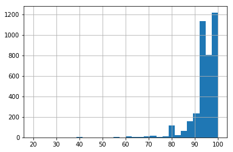

```python
# Let's first see the distrinution of the overall ratings.

df.review_scores_rating.hist(bins=30);
print('Average review rating:', df.review_scores_rating.mean())
```

Let's go back to the first step that I decided to use number of reviews per month as the indicator for popularity instead of total sales (which we do not have info about) or overall rating. Here is a brief explanation of why I did not use the rating score as the target for my random forest regressor. As we can see from the rating distribution as well as average score (94.5) above, the rating itself is not a very good indication of popularity/satisfaction for the house/apt because people tend to be very generous about the ratings they gave. Therefore, I came up with a new indicator of the popularity, which is the number of reviews received each month. If we assume most people leave good ratings along with written reviews (as we see from the rating distribution), it is reasonable to believe that properties with lots of reviews are the ones that are nice and popular.

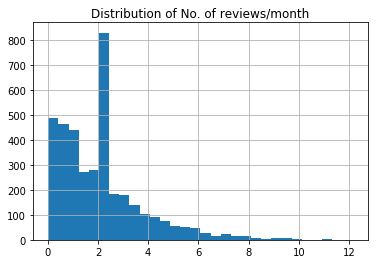

```python
df['reviews_per_month'].hist(bins=30)
plt.title('Distribution of No. of reviews/month');
```

It looks like monthly review is distributed between 0 and 12, with a great number of properties having about 2 reviews per month.

In order to simplify visualization of the relationship between popularity and other features, I will divide all properties into 3 groups according to their popularity (reviews per month). The division will be made based on percentiles, therefore there will be equal (or very similar if not) number of properties in each groups.

```python
# the properties were divided into 3 groups based on their popularity (reviews they got per month)

df['popularity'] = pd.qcut(df['reviews_per_month'],3,labels=['low','medium','high'])
```

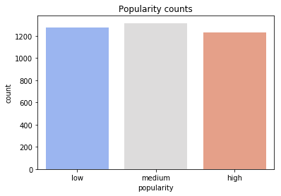

```python
sns.countplot(df['popularity'],palette='coolwarm') # see how many house/apt fall in each group
plt.title('Popularity counts');
```

Now we have three popularity groups. Next, let's look at one of the important feature we discovered from random forest feature importance analysis - minimum nights required for stay.

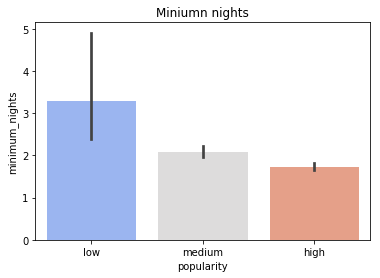

```python
sns.barplot(x=df.popularity,y=df.minimum_nights,palette='coolwarm') # see average apt/house price in each group
plt.title('Miniumn nights');
```

The ones with lowest popularity require longest minimum stay (with a huge error bar though), suggesting that people prefer flexible policy on their stay.

Next, let's see the price for each popularity type.

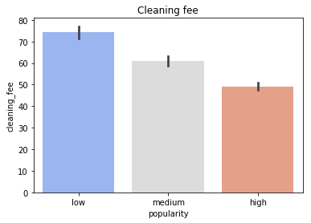

```python
sns.barplot(x=df.popularity,y=df.cleaning_fee,palette='coolwarm') # see cleaning fee in each group
plt.title('Cleaning fee');
```

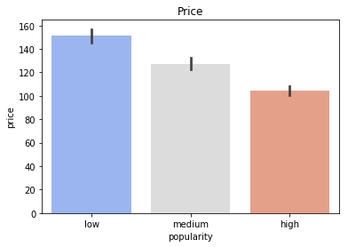

```python
sns.barplot(x=df.popularity,y=df.price,palette='coolwarm') # see average price in each group
plt.title('Price');
```

Interestingly, we can see a clear pattern here that people like to rent house/apt with low price.

Then how about availability?

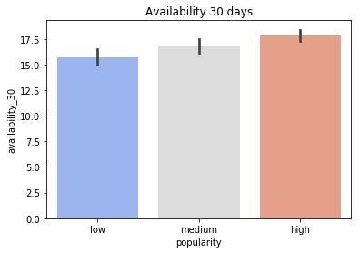

```python
sns.barplot(x=df.popularity,y=df.availability_30,palette='coolwarm') # see 30 day availability in each group
plt.title('Availability 30 days');
```

Of course, not all properties are available for entire month for rent because some people only rent their house/apt when they are not around. And it makes sense that these type of properties received less reviews because they had less guests/visits. Thus, it is hard to know for what reason the properties were not available (could be already rent out or just not available), but there is a slight trend that they are more popular if they have greater availability.

Next, we assumed that most listings on airbnb website generally received good ratings regardless of their popularity. But is it really that case?

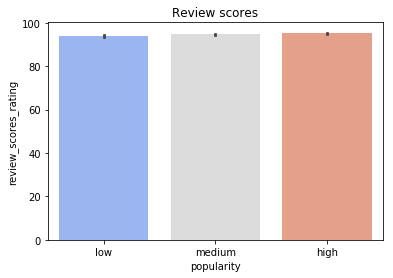

```python
sns.barplot(x=df.popularity,y=df.review_scores_rating,palette='coolwarm') # see average rating in each group
plt.title('Review scores');
```

Yes, it is!!! So hosts, please keep in mind that number of reviews is more important than scores, so try your best to increase the number of reviews and convince every visitor to leave a review after their stay!

However, there is a trap in this review system. You'll make a huge mistake if you think rating is not important! Hosts have been complaining about the airbnb rating system. Here's an example. https://community.withairbnb.com/t5/Host-Voice/Agreed-Airbnb-s-rating-system-kinda-sucks/idi-p/573267

Basically, because everyone's rating is so high, just one bad rating and review (especially when you don't have a lot of reviews yet) can dramatically change the 'level' of your property and therefore airbnb will probably give you warning for 'low' scores that indeed is not a bad score at all. Thus I personally think that number of reviews and rating are equally important for hosts.

Next, let's explore some features that are not on the top 5 list.

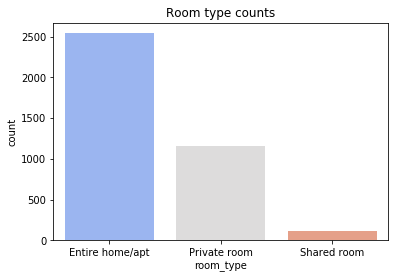

```python
sns.countplot(df['room_type'],palette='coolwarm') # see what type of room people prefer
plt.title('Room type counts');
```

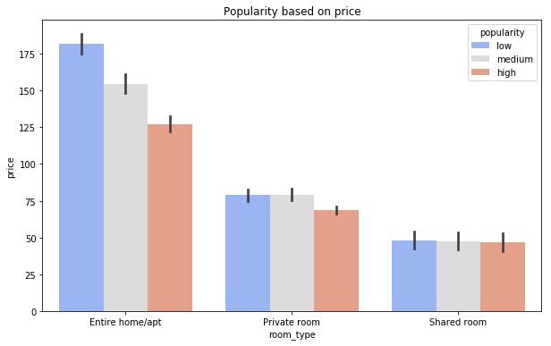

```python
plt.figure(figsize=(10,6))
sns.barplot(df.room_type,df.price,hue=df.popularity, palette='coolwarm')
plt.title('Popularity based on price');
```

From these two graphs, we can see that most of the listings are entire home or apartment. Interestingly, from the second graph left panel we can see that low-price entire home/apt are most popular and high-price entire home/apt are least popular. This indicates that most people prefer cheap but private place.

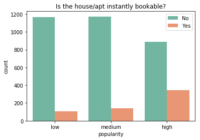

```python
sns.countplot(df.popularity,hue=df.instant_bookable,palette='Set2')
plt.title('Is the house/apt instantly bookable?')
plt.legend(['No','Yes']);
```

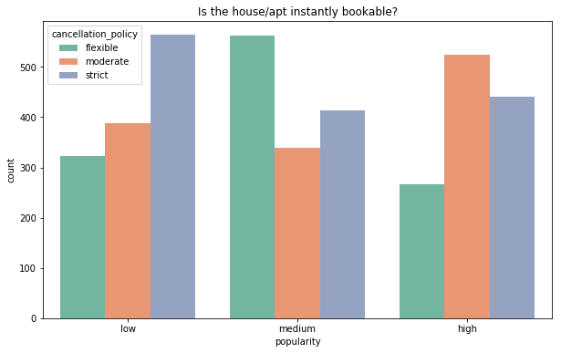

```python
plt.figure(figsize=(10,6))
sns.countplot(df.popularity,hue=df.cancellation_policy,palette='Set2',
              hue_order=['flexible','moderate','strict'])
plt.title('Is the house/apt instantly bookable?');
```

Instant booking and cancellation policies were also examined. The properties with high popularity are open to instant bookings more than other properties, and their cancellation polity is moderate.

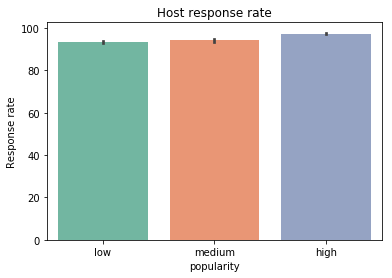

```python
sns.barplot(df.popularity,df.host_response_rate,palette='Set2')
plt.title('Host response rate')
plt.ylabel('Response rate');
```

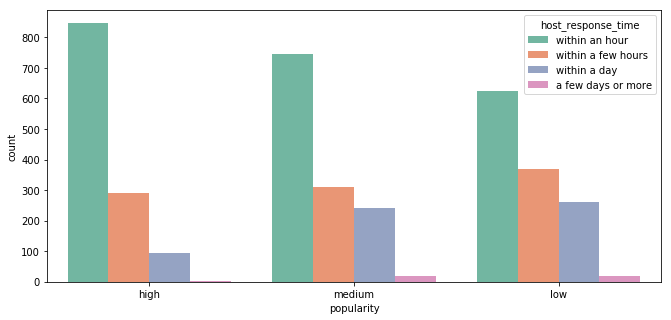

```python
plt.figure(figsize=(11,5))
sns.countplot(df.popularity, hue=df.host_response_time,
              order=['high','medium','low'],
              hue_order=['within an hour','within a few hours','within a day','a few days or more'],
              palette='Set2');
```

Properties in popularity groups tend to show similar response rate but slightly different response time. Most of the hosts do indeed respond within an hour of the inquiry, but the popular properties are more likely to do so than other properties.

Finally, let's look at some popular amenities provided in the properties.

```python
df.amenities[0]
```

```
'{TV,"Cable TV",Internet,"Wireless Internet","Air Conditioning",Kitchen,Heating,"Family/Kid Friendly",Washer,Dryer}'
```

```python
# see most popular amenities

df.amenities = df.amenities.apply(lambda x: x if x is np.NAN else x[1:-1].replace('"','').split(','))

from collections import Counter
df.ame_counts = df.amenities.apply(lambda x: Counter(x))

items = Counter()
for item in df.ame_counts:
    items = items + item

pd.DataFrame.from_dict(items, orient='index').sort_values(0,ascending=False)[:15]
```

|  | 0 |
| --- | --- |
| Wireless Internet | 3667 |
| Heating | 3627 |
| Kitchen | 3423 |
| Smoke Detector | 3281 |
| Essentials | 3237 |
| Dryer | 2997 |
| Washer | 2992 |
| Internet | 2811 |
| Shampoo | 2670 |
| TV | 2574 |
| Carbon Monoxide Detector | 2485 |
| Fire Extinguisher | 2196 |
| Free Parking on Premises | 2167 |
| Family/Kid Friendly | 1963 |
| First Aid Kit | 1680 |

The top 15 popular amaneties are listed above. Some are really basic, such as internet and smoke detector, while some are not easily seen in a regular hotel, for example the first aid kit.

In summary, in this notebook, I tried to analyze what makes an airbnb property popular than others. Like I mentioned earlier, the sales would have been the best measure in the analysis; but unfortunately, there is no easy and straitforward way to calculate the sales from given dataset (I might be wrong, correct me if there is a way to do so). Therefore, I used the number of reviews each month to see what differs the popular properties from others.

I first examined important features using feature importance analysis in random forest regressor, and used some graphs to visualize these features. Then I also looked at some other features that might be helpful for future improvement for the hosts.

This analysis primarily focuses on features that can be improved/upgraded by the hosts, and this is why I did not include analysis about the neigbourhood etc. You can't just move to a popular neigbourbood because it's popular, right?

Finally, I am a data enthusiast who just started to learn ds skills and coding, so any feedback is greatly appreciated!